# MIT_Practice Project_FIFA_Solution_V2

## Q 1: Import the necessary libraries & explain them

```python
#import ____ as np
#import pandas as pd

import seaborn as sns
import matplotlib.pyplot as plt
%matplotlib inline

import scipy.stats as stats

import statistics
```

```python
# copy the above code here, remove _____ & write the approrpiate library name

import numpy as np
import pandas as pd
import seaborn as sns
import matplotlib.pyplot as plt
%matplotlib inline

import scipy.stats as stats

import statistics
```

### Ans 1:

Numpy NumPy is used for handling Numbers, Numerical analysis. It is the fundamental package for array computing with Python. Pandas Pandas are used to process the data. Pandas contains data structures and data manipulation tools designed for data cleaning and analysis.

## Q 2: Which library is used to read any dataset & how do you read it?

```python
#Read the dataset:
fifa=pd.read_csv("WorldCups.csv")
```

## Q3. Show the last 10 records of the dataset. How many columns are there, name them.

```python
fifa.tail(10)
```

|  | Year | Country | Winner | Runners-Up | Third | Fourth | GoalsScored | QualifiedTeams | MatchesPlayed | Attendance |
| --- | --- | --- | --- | --- | --- | --- | --- | --- | --- | --- |
| 10 | 1978 | Argentina | Argentina | Netherlands | Brazil | Italy | 102 | 16 | 38 | 1.545.791 |
| 11 | 1982 | Spain | Italy | Germany FR | Poland | France | 146 | 24 | 52 | 2.109.723 |
| 12 | 1986 | Mexico | Argentina | Germany FR | France | Belgium | 132 | 24 | 52 | 2.394.031 |
| 13 | 1990 | Italy | Germany FR | Argentina | Italy | England | 115 | 24 | 52 | 2.516.215 |
| 14 | 1994 | USA | Brazil | Italy | Sweden | Bulgaria | 141 | 24 | 52 | 3.587.538 |
| 15 | 1998 | France | France | Brazil | Croatia | Netherlands | 171 | 32 | 64 | 2.785.100 |
| 16 | 2002 | Korea/Japan | Brazil | Germany | Turkey | Korea Republic | 161 | 32 | 64 | 2.705.197 |
| 17 | 2006 | Germany | Italy | France | Germany | Portugal | 147 | 32 | 64 | 3.359.439 |
| 18 | 2010 | South Africa | Spain | Netherlands | Germany | Uruguay | 145 | 32 | 64 | 3.178.856 |
| 19 | 2014 | Brazil | Germany | Argentina | Netherlands | Brazil | 171 | 32 | 64 | 3.386.810 |

## Q4. Show the first 10 records of the dataset.

```python
fifa.head(10)
```

|  | Year | Country | Winner | Runners-Up | Third | Fourth | GoalsScored | QualifiedTeams | MatchesPlayed | Attendance |
| --- | --- | --- | --- | --- | --- | --- | --- | --- | --- | --- |
| 0 | 1930 | Uruguay | Uruguay | Argentina | USA | Yugoslavia | 70 | 13 | 18 | 590.549 |
| 1 | 1934 | Italy | Italy | Czechoslovakia | Germany | Austria | 70 | 16 | 17 | 363.000 |
| 2 | 1938 | France | Italy | Hungary | Brazil | Sweden | 84 | 15 | 18 | 375.700 |
| 3 | 1950 | Brazil | Uruguay | Brazil | Sweden | Spain | 88 | 13 | 22 | 1.045.246 |
| 4 | 1954 | Switzerland | Germany FR | Hungary | Austria | Uruguay | 140 | 16 | 26 | 768.607 |
| 5 | 1958 | Sweden | Brazil | Sweden | France | Germany FR | 126 | 16 | 35 | 819.810 |
| 6 | 1962 | Chile | Brazil | Czechoslovakia | Chile | Yugoslavia | 89 | 16 | 32 | 893.172 |
| 7 | 1966 | England | England | Germany FR | Portugal | Soviet Union | 89 | 16 | 32 | 1.563.135 |
| 8 | 1970 | Mexico | Brazil | Italy | Germany FR | Uruguay | 95 | 16 | 32 | 1.603.975 |
| 9 | 1974 | Germany | Germany FR | Netherlands | Poland | Brazil | 97 | 16 | 38 | 1.865.753 |

## Q5. What do you mean by the dimension of the dataset.

```python
fifa.shape
```

```
(20, 10)
```

## Q6. What do you understand by the size of the dataset.

```python
fifa.size
```

```
200
```

## Q7. What are the dtypes of all the variables in the data set. Use info() to get all the information about the dataset

```python
fifa.info()
```

```
<class 'pandas.core.frame.DataFrame'>
RangeIndex: 20 entries, 0 to 19
Data columns (total 10 columns):
 #   Column          Non-Null Count  Dtype
---  ------          --------------  -----
 0   Year            20 non-null     int64
 1   Country         20 non-null     object
 2   Winner          20 non-null     object
 3   Runners-Up      20 non-null     object
 4   Third           20 non-null     object
 5   Fourth          20 non-null     object
 6   GoalsScored     20 non-null     int64
 7   QualifiedTeams  20 non-null     int64
 8   MatchesPlayed   20 non-null     int64
 9   Attendance      20 non-null     object
dtypes: int64(4), object(6)
memory usage: 1.7+ KB
```

## Q8. What do you mean by Missing Values? Are there any missing values?

```python
fifa.isnull().values.any()
```

```
False
```

## Q9. What does summary of data represent? Take one column/variable from the output table and explain all the statistical measures.

```python
fifa.iloc[:,0:8].describe()
```

|  | Year | GoalsScored | QualifiedTeams |
| --- | --- | --- | --- |
| count | 20.000000 | 20.000000 | 20.000000 |
| mean | 1974.800000 | 118.950000 | 21.250000 |
| std | 25.582889 | 32.972836 | 7.268352 |
| min | 1930.000000 | 70.000000 | 13.000000 |
| 25% | 1957.000000 | 89.000000 | 16.000000 |
| 50% | 1976.000000 | 120.500000 | 16.000000 |
| 75% | 1995.000000 | 145.250000 | 26.000000 |
| max | 2014.000000 | 171.000000 | 32.000000 |

### Ans 9:

The variable that we are going to explain over here with respect to the summary statistics is 'GoalsScored'. We notice that there are 20 observations of GoalsScored with a mean of 118.95 and the median as 120.5. The first quartile (or the 25% percentile) is at 89 and the third quartile (or the 75% percentile) is 145.25. The deviation about the mean (which is the standard deviation) is 32.97. The range of the variable (maximum value - minimum value) is 101.

## Q10. Fill in correct library name & run the below plot :

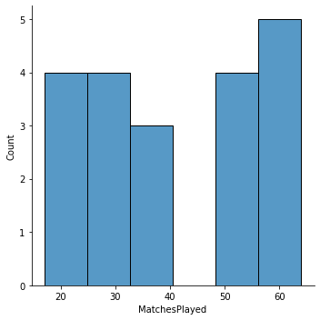

```python
sns.displot(fifa['MatchesPlayed'],kde=False,bins=6)
plt.show()
```

## Q 11. Which 'Country' had won maximum times'?Explain your answer

```python
fifa_count=fifa['Winner'].value_counts()
print(fifa_count)
```

```
Brazil        5
Italy         4
Germany FR    3
Uruguay       2
Argentina     2
France        1
Spain         1
England       1
Germany       1
Name: Winner, dtype: int64
```

## Q12.

### 12.1 What is the mean of the variable 'Qualified teams'?

### 12.2 What is the median of the variable 'Qualified teams'?

### 12.3 What is the mode of the variable 'Qualified teams'?

### Expalin your answer

```python
m1 = fifa['QualifiedTeams'].mean()
print(m1)
m2 = fifa['QualifiedTeams'].median()
print(m2)
m3= fifa['QualifiedTeams'].mode()[0]
print(m3)
```

```
21.25
16.0
16
```

Ans: The mean for QualifiedTeams is 21.25, whereas median is 16 & mode is equal to median i.e. 16 as well

## Q13. In how many World Cups the number of Qualified Teams are greater than the mean level of 'Qualified teams'?

```python
fifa[fifa['QualifiedTeams']>m1][['Year','Country']]
```

|  | Year | Country |
| --- | --- | --- |
| 11 | 1982 | Spain |
| 12 | 1986 | Mexico |
| 13 | 1990 | Italy |
| 14 | 1994 | USA |
| 15 | 1998 | France |
| 16 | 2002 | Korea/Japan |
| 17 | 2006 | Germany |
| 18 | 2010 | South Africa |
| 19 | 2014 | Brazil |

## Q14. Which World Cups got the minimum 'GoalsScored' ?

```python
fifa[fifa['GoalsScored']==fifa['GoalsScored'].min()][['Year','Country']]
```

|  | Year | Country |
| --- | --- | --- |
| 0 | 1930 | Uruguay |
| 1 | 1934 | Italy |

## Q15. Plot the pairplots of 'GoalsScored', 'QualifiedTeams', 'MatchesPlayed' to get the desired Output.

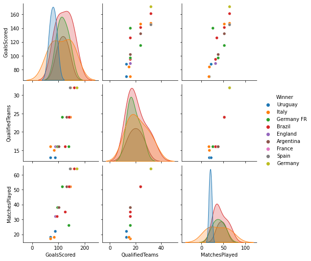

```python
import warnings
warnings.filterwarnings('ignore')

sns.pairplot(data=fifa,vars=['GoalsScored', 'QualifiedTeams', 'MatchesPlayed'],hue='Winner')
plt.show()
```

## Q16. Plot the scatterplot between 'Country' and 'Year'.

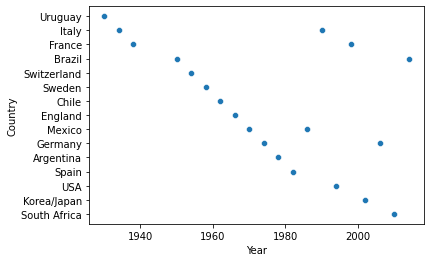

```python
sns.scatterplot(data = fifa, x= "Year", y = "Country")
plt.show()
```

## Q17. Show a barplot for variable Winner to understand the number of times a Country won in between 1930 to 2014

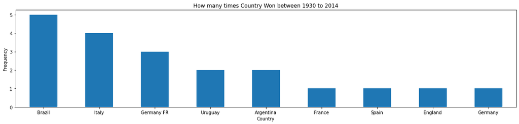

```python
fifa.Winner.value_counts().plot(kind='bar', rot=0)
fig_size = plt.rcParams["figure.figsize"]
fig_size[0]=20
plt.title('How many times Country Won between 1930 to 2014')
plt.xlabel('Country')
plt.ylabel('Frequency')
plt.show()
```

## Q 18. Show boxplot for GoalsScored variable.Is their any Outlier (Yes/No)?¶

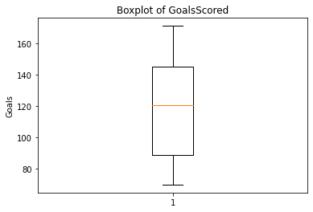

```python
plt.boxplot(fifa['GoalsScored'])

plt.title('Boxplot of GoalsScored')
plt.ylabel('Goals')
plt.show()
```

Ans: No Outlier

### Q 19. Plot the correlation matrix in the form of a heatmap.

```python
corr_matrix = fifa.corr()

corr_matrix
```

|  | Year | GoalsScored | QualifiedTeams | MatchesPlayed |
| --- | --- | --- | --- | --- |
| Year | 1.000000 | 0.829886 | 0.895565 | 0.972473 |
| GoalsScored | 0.829886 | 1.000000 | 0.866201 | 0.876201 |
| QualifiedTeams | 0.895565 | 0.866201 | 1.000000 | 0.949164 |
| MatchesPlayed | 0.972473 | 0.876201 | 0.949164 | 1.000000 |

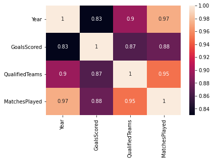

```python
sns.heatmap(corr_matrix, annot = True)

# display the plot
plt.show()
```